# MITx_4_Trees

# While using randomForest

Now build a random forest model on the training data, using the same independent variables as in the previous problem – again, don’t forget to remove the isB variable. Just use the default parameter values for ntree and nodesize (you don’t need to include these arguments at all). Set the seed to 1000 right before building your model. (Remember that you might get a slightly different result even if you set the random seed.)

What is the test set accuracy of your random forest model?

```r
RanFor2 <- randomForest(letter ~ . - isB, data = train_2)
predRF_2 <- predict(RanFor2, newdata = test_2)
table(predRF_2, test_2$letter)
```

```
##
## predRF_2   A   B   P   R
##        A 391   0   0   0
##        B   0 379   4  12
##        P   3   2 394   0
##        R   1   2   3 367
```

```r
z <- table(predRF_2, test_2$letter)
acc_RF <- sum(diag(z))/sum(z)
acc_RF
```

```
## [1] 0.9826701
```

## Predicting Earnings from Census Data

The United States government periodically collects demographic information by conducting a census.

In this problem, we are going to use census information about an individual to predict how much a person earns – in particular, whether the person earns more than $50,000 per year. This data comes from the UCI Machine Learning Repository.

```r
census <- read.csv("census.csv")
census$over50k <- ifelse(census$over50k == " <=50K", 0, 1)
str(census)
```

```
## 'data.frame':    31978 obs. of  13 variables:
##  $ age          : int  39 50 38 53 28 37 49 52 31 42 ...
##  $ workclass    : chr  " State-gov" " Self-emp-not-inc" " Private" " Private" ...
##  $ education    : chr  " Bachelors" " Bachelors" " HS-grad" " 11th" ...
##  $ maritalstatus: chr  " Never-married" " Married-civ-spouse" " Divorced" " Married-civ-spouse" ...
##  $ occupation   : chr  " Adm-clerical" " Exec-managerial" " Handlers-cleaners" " Handlers-cleaners" ...
##  $ relationship : chr  " Not-in-family" " Husband" " Not-in-family" " Husband" ...
##  $ race         : chr  " White" " White" " White" " Black" ...
##  $ sex          : chr  " Male" " Male" " Male" " Male" ...
##  $ capitalgain  : int  2174 0 0 0 0 0 0 0 14084 5178 ...
##  $ capitalloss  : int  0 0 0 0 0 0 0 0 0 0 ...
##  $ hoursperweek : int  40 13 40 40 40 40 16 45 50 40 ...
##  $ nativecountry: chr  " United-States" " United-States" " United-States" " United-States" ...
##  $ over50k      : num  0 0 0 0 0 0 0 1 1 1 ...
```

```r
summary(census)
```

```
##       age         workclass          education         maritalstatus
##  Min.   :17.00   Length:31978       Length:31978       Length:31978
##  1st Qu.:28.00   Class :character   Class :character   Class :character
##  Median :37.00   Mode  :character   Mode  :character   Mode  :character
##  Mean   :38.58
##  3rd Qu.:48.00
##  Max.   :90.00
##   occupation        relationship           race               sex
##  Length:31978       Length:31978       Length:31978       Length:31978
##  Class :character   Class :character   Class :character   Class :character
##  Mode  :character   Mode  :character   Mode  :character   Mode  :character
##
##
##
##   capitalgain     capitalloss       hoursperweek   nativecountry
##  Min.   :    0   Min.   :   0.00   Min.   : 1.00   Length:31978
##  1st Qu.:    0   1st Qu.:   0.00   1st Qu.:40.00   Class :character
##  Median :    0   Median :   0.00   Median :40.00   Mode  :character
##  Mean   : 1064   Mean   :  86.74   Mean   :40.42
##  3rd Qu.:    0   3rd Qu.:   0.00   3rd Qu.:45.00
##  Max.   :99999   Max.   :4356.00   Max.   :99.00
##     over50k
##  Min.   :0.0000
##  1st Qu.:0.0000
##  Median :0.0000
##  Mean   :0.2406
##  3rd Qu.:0.0000
##  Max.   :1.0000
```

```r
# Splitting the data
set.seed(2000)
split_census <- sample.split(census$over50k, SplitRatio = 0.6)

train_census <- subset(census, split_census == TRUE)

test_census <- subset(census, split_census == FALSE)

# Logistic regression

logCensus <- glm(over50k ~ ., family = "binomial", data = train_census)
```

```
## Warning: glm.fit: fitted probabilities numerically 0 or 1 occurred
```

```r
summary(logCensus)
```

```
##
## Call:
## glm(formula = over50k ~ ., family = "binomial", data = train_census)
##
## Deviance Residuals:
##     Min       1Q   Median       3Q      Max
## -5.1065  -0.5037  -0.1804  -0.0008   3.3383
##
## Coefficients: (1 not defined because of singularities)
##                                            Estimate Std. Error z value Pr(>|z|)
## (Intercept)                              -8.658e+00  1.379e+00  -6.279 3.41e-10
## age                                       2.548e-02  2.139e-03  11.916  < 2e-16
## workclass Federal-gov                     1.105e+00  2.014e-01   5.489 4.03e-08
## workclass Local-gov                       3.675e-01  1.821e-01   2.018 0.043641
## workclass Never-worked                   -1.283e+01  8.453e+02  -0.015 0.987885
## workclass Private                         6.012e-01  1.626e-01   3.698 0.000218
## workclass Self-emp-inc                    7.575e-01  1.950e-01   3.884 0.000103
## workclass Self-emp-not-inc                1.855e-01  1.774e-01   1.046 0.295646
## workclass State-gov                       4.012e-01  1.961e-01   2.046 0.040728
## workclass Without-pay                    -1.395e+01  6.597e+02  -0.021 0.983134
## education 11th                            2.225e-01  2.867e-01   0.776 0.437738
## education 12th                            6.380e-01  3.597e-01   1.774 0.076064
## education 1st-4th                        -7.075e-01  7.760e-01  -0.912 0.361897
## education 5th-6th                        -3.170e-01  4.880e-01  -0.650 0.516008
## education 7th-8th                        -3.498e-01  3.126e-01  -1.119 0.263152
## education 9th                            -1.258e-01  3.539e-01  -0.355 0.722228
## education Assoc-acdm                      1.602e+00  2.427e-01   6.601 4.10e-11
## education Assoc-voc                       1.541e+00  2.368e-01   6.506 7.74e-11
## education Bachelors                       2.177e+00  2.218e-01   9.817  < 2e-16
## education Doctorate                       2.761e+00  2.893e-01   9.544  < 2e-16
## education HS-grad                         1.006e+00  2.169e-01   4.638 3.52e-06
## education Masters                         2.421e+00  2.353e-01  10.289  < 2e-16
## education Preschool                      -2.237e+01  6.864e+02  -0.033 0.973996
## education Prof-school                     2.938e+00  2.753e-01  10.672  < 2e-16
## education Some-college                    1.365e+00  2.195e-01   6.219 5.00e-10
## maritalstatus Married-AF-spouse           2.540e+00  7.145e-01   3.555 0.000378
## maritalstatus Married-civ-spouse          2.458e+00  3.573e-01   6.880 6.00e-12
## maritalstatus Married-spouse-absent      -9.486e-02  3.204e-01  -0.296 0.767155
## maritalstatus Never-married              -4.515e-01  1.139e-01  -3.962 7.42e-05
## maritalstatus Separated                   3.609e-02  1.984e-01   0.182 0.855672
```

[output cut: 162 more lines]

```
## nativecountry Thailand
## nativecountry Trinadad&Tobago
## nativecountry United-States
## nativecountry Vietnam
## nativecountry Yugoslavia
## ---
## Signif. codes:  0 '***' 0.001 '**' 0.01 '*' 0.05 '.' 0.1 ' ' 1
##
## (Dispersion parameter for binomial family taken to be 1)
##
##     Null deviance: 21175  on 19186  degrees of freedom
## Residual deviance: 12104  on 19090  degrees of freedom
## AIC: 12298
##
## Number of Fisher Scoring iterations: 15
```

# Logistic Regression Model

What is the accuracy of the model on the testing set? Use a threshold of 0.5. (You might see a warning message when you make predictions on the test set - you can safely ignore it.)

```r
predLogEarnings <- predict(logCensus, newdata = test_census, type = "response")
```

```
## Warning in predict.lm(object, newdata, se.fit, scale = 1, type = if (type == :
## prediction from a rank-deficient fit may be misleading
```

```r
table(test_census$over50k, predLogEarnings >= 0.5)
```

```
##
##     FALSE TRUE
##   0  9051  662
##   1  1190 1888
```

```r
(9051+1888)/nrow(test_census)
```

```
## [1] 0.8552107
```

```r
# Baseline accuracy
table(test_census$over50k)/nrow(test_census)
```

```
##
##         0         1
## 0.7593621 0.2406379
```

# AUC with ROCR Package

What is the area-under-the-curve (AUC) for this model on the test set?

```r
library(ROCR)

ROCRpred <- prediction(predLogEarnings, test_census$over50k)
as.numeric(performance(ROCRpred, "auc")@y.values)
```

```
## [1] 0.9061598
```

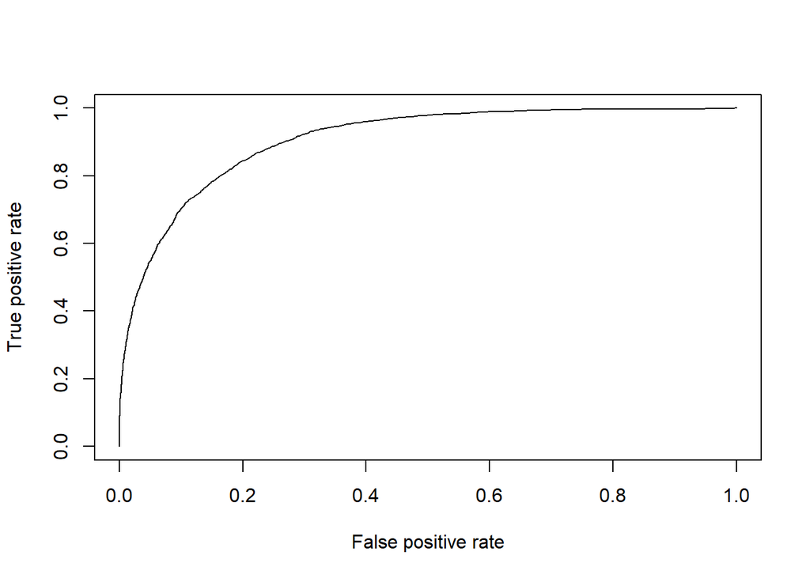

```r
perf1 <- performance(ROCRpred, "tpr", "fpr")
plot(perf1)
```

# Start of CART Model

We have just seen how the logistic regression model for this data achieves a high accuracy. Moreover, the significances of the variables give us a way to gauge which variables are relevant for this prediction task. However, it is not immediately clear which variables are more important than the others, especially due to the large number of factor variables in this problem.

Let us now build a classification tree to predict “over50k”. Use the training set to build the model, and all of the other variables as independent variables. Use the default parameters, so don’t set a value for minbucket or cp. Remember to specify method=“class” as an argument to rpart, since this is a classification problem. After you are done building the model, plot the resulting tree.

How many splits does the tree have in total?

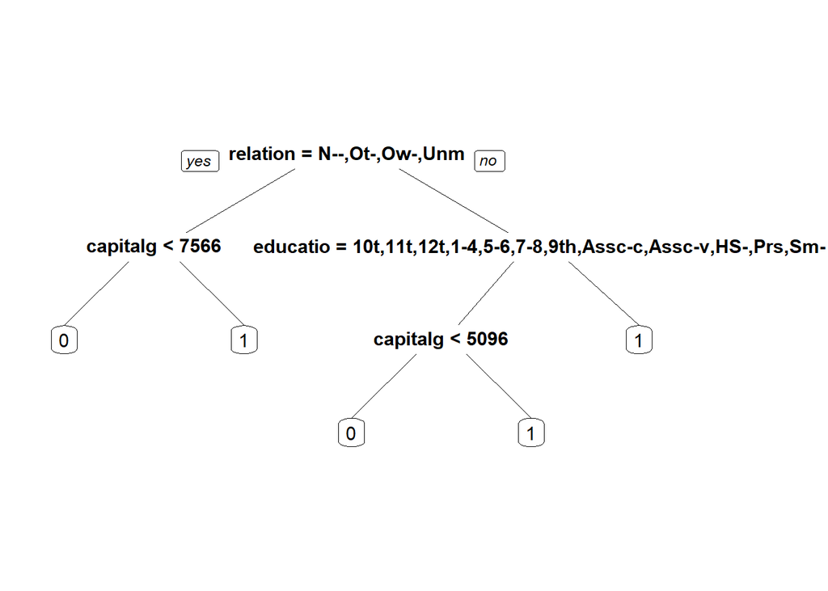

```r
censusTree <- rpart(over50k ~ ., data = train_census, method = "class")
prp(censusTree)
```

```r
# Accuracy

predTreeCensus <- predict(censusTree, newdata = test_census, type = "class")
table(predTreeCensus, test_census$over50k)
```

```
##
## predTreeCensus    0    1
##              0 9243 1482
##              1  470 1596
```

```r
(9243+1596)/nrow(test_census)
```

```
## [1] 0.8473927
```